# Replication analysis: meta-analysis of GASP U-BIOPRED and GERA cohorts

Code: src/QC_postimputation.R

```r
#!/usr/bin/env Rscript


suppressMessages(library(tidyverse))
suppressMessages(library(data.table))
suppressMessages(library(plyr))


#Imputation quality checks, from R.A. script 1hrc_imputation.sh

#Not needed because I have 'cd' command in the .sh file, here as a reference if I want to set scratch as a working directory:
#setwd(""/lustre/alice3/scratch/gen1/nnp5/Post_GWAS/tmp_data/GASP_UBIO_UKB_imputed")

for (i in 1:22){
    assign(paste0("chr", i), fread(paste0("chr_", i,"/chr",i,".info.gz"), header = T) )
    }

df <- rbind(chr1, chr2, chr3, chr4, chr5, chr6, chr7, chr8, chr9, chr10, chr11, chr12, chr13, chr14, chr15, chr16, chr17, chr18, chr19, chr20, chr21, chr22)

rm(list = ls(pattern = "^chr"))

df$Rsq <- as.numeric(df$Rsq)
df$MAF <- as.numeric(df$MAF)

common <- subset(df, MAF >= 0.05)
print("N of common variants:")
print(dim(common)[1])
lowfrq <- subset(df, MAF < 0.05)
lowfrq <- subset(lowfrq, MAF >= 0.01)
print("N of lowfrq variants:")
print(dim(lowfrq)[1])
rare <- subset(df, MAF < 0.01)
print("N of rare variants:")
print(dim(rare)[1])

png("/home/n/nnp5/PhD/PhD_project/Post_GWAS/output/imputation_quality_by_frequency.png", width=1000, height=1000)
par(mfrow=c(3,1), mar=c(5,5,5,5), bty="l",yaxs="i",xaxs="i")
hist(common$Rsq, main="Common variants", xlab="Imputation Quality", cex.lab=2, cex.axis=2, cex.main=2, col="darkred")
hist(lowfrq$Rsq, main="Low Frequency variants", xlab="Imputation Quality", cex.lab=2, cex.axis=2, cex.main=2, col="darkred")
hist(rare$Rsq, main="Rare variants", xlab="Imputation Quality", cex.lab=2, cex.axis=2, cex.main=2, col="darkred")
dev.off()


#zoom-in of rare variants excluding the ultra-rare variants:
#rare_noultra <- subset(rare, MAF >= 0.001)
#print("N of rare no-ultra-rare variants:")
#print(dim(rare_noultra)[1])
#ultra_rare <- subset(df, MAF < 0.001)
#print("N of ultra-rare variants:")
#print(dim(ultra_rare)[1])

#png("/home/n/nnp5/PhD/PhD_project/Post_GWAS/output/imputation_quality_by_frequency_rare_ultrarare.png", width=1000, height=1000)
#par(mfrow=c(2,1), mar=c(5,5,5,5), bty="l",yaxs="i",xaxs="i")
#hist(rare_noultra$Rsq, main="Rare variants without ultra-rare variants", xlab="Imputation Quality", cex.lab=2, cex.axis=2, cex.main=2, col="darkred")
#hist(ultra_rare$Rsq, main="Ultra-rare variants", xlab="Imputation Quality", cex.lab=2, cex.axis=2, cex.main=2, col="darkred")
#dev.off()
```

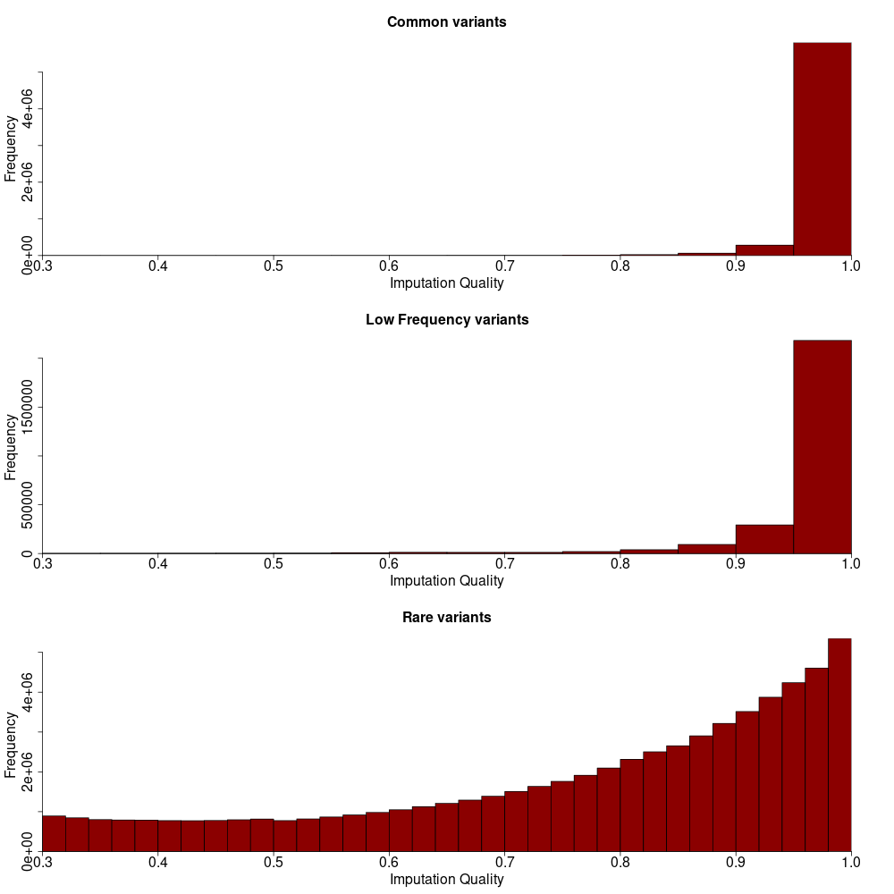

Figure 1. Info imputation score frequency according to MAF bins.

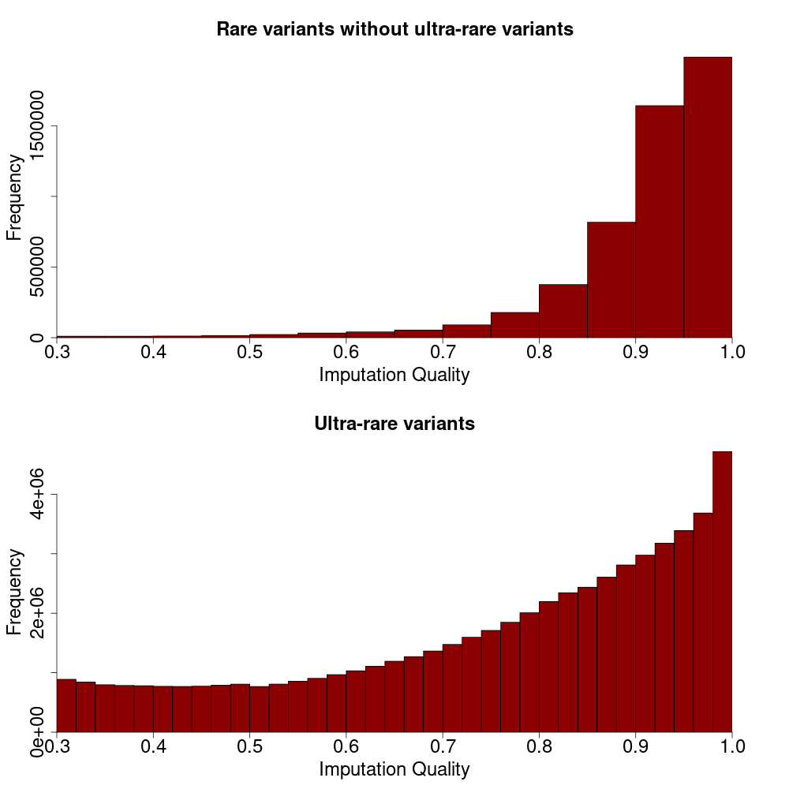

Figure 2. Info imputation score for rare and ultra-rare only variants.

In conclusion, the imputation showed good quality data for common, low and rare frequency variants. I will run the association analysis with variants with INFO > 0.3 and MAF>= 0.01; therefore the imputation data can be used as confirmed by the quality checks.

#### Genome-wide association analysis

Code: src/GWAS_UBIOPRED_GASP/liftover_and_plink_QC_preregenie.sh

```r
#!/bin/bash

#LifOver genotyped data since imputed data are in Build38. Then, QC for link file for REGENIE step 1

tmp_data="/scratch/gen1/nnp5/Post_GWAS/tmp_data"
PATH_wd="/home/n/nnp5/PhD/PhD_project/Post_GWAS"
software="/home/n/nnp5/software"
cd ${PATH_wd}
mkdir ${tmp_data}/GUU

#LiftOver form Build37 to Build38
#split in chromosome:
module load plink2
for chr in {1..22}; do \
plink2 \
    --bfile ${tmp_data}/all_overlapping \
    --chr $chr --make-bed \
    --out ${tmp_data}/GUU/all_overlapping_${chr}; \
done

##create ped file:
#GUU: gasp, ubiopred, biobank
for chr in {1..22}; do \
${software}/plink2 \
    --bfile ${tmp_data}/GUU/all_overlapping_${chr} \
    --export ped \
    --out ${tmp_data}/GUU/guu_${chr};
done

##liftover:
for chr in {1..22}; do \
python ${software}/liftOverPlink/liftOverPlink.py \
    -m ${tmp_data}/GUU/guu_${chr}.map \
    -p ${tmp_data}/GUU/guu_${chr}.ped \
    -o ${tmp_data}/GUU/guu_${chr}_b38 \
    -c ${software}/hg19ToHg38.over.chain.gz \
    -e ${software}/liftOver;
done

##remove bad lifted/unlifted variants
for chr in {1..22}; do \
python ${software}/liftOverPlink/rmBadLifts.py \
    --map ${tmp_data}/GUU/guu_${chr}_b38.map \
    --out ${tmp_data}/GUU/guu_${chr}_good_lifted \
    --log ${tmp_data}/GUU/guu_${chr}_bad_lifted.dat;
done

for chr in {1..22}; do \
cut -f 2 ${tmp_data}/GUU/guu_${chr}_bad_lifted.dat > ${tmp_data}/GUU/guu_${chr}_to_exclude.dat;
cut -f 4 ${tmp_data}/GUU/guu_${chr}_b38.bed.unlifted | sed "/^#/d" >> ${tmp_data}/GUU/guu_${chr}_to_exclude.dat;
done


#Remove the alternative contig: TO DO SPECIFIC TO EACH STUDY
#alternative contig in chromosome 1,4,7,8,14,17,19,22:
for chr in 1 7 8 17 19 22; do \
contig_to_exclude=$(grep "_alt\|_random" ${tmp_data}/GUU/guu_${chr}_b38.map | awk -F "\t" '{print $1}' | tr '\n' ' ');
${software}/plink2 \
    --pedmap ${tmp_data}/GUU/guu_${chr}_b38 \
    --make-pgen \
    --sort-vars \
    --allow-extra-chr --not-chr $contig_to_exclude \
    --out ${tmp_data}/GUU/guu_${chr}_b38_lifted \
    --exclude ${tmp_data}/GUU/guu_${chr}_to_exclude.dat;
${software}/plink2 \
    --pfile ${tmp_data}/GUU/guu_${chr}_b38_lifted \
    --make-bed \
    --out ${tmp_data}/GUU/guu_${chr}_b38_lifted;
done

for chr in 2 3 4 5 6 9 10 11 12 13 14 15 16 18 20 21; do \
${software}/plink2 \
    --pedmap ${tmp_data}/GUU/guu_${chr}_b38 \
    --make-pgen \
    --sort-vars \
    --out ${tmp_data}/GUU/guu_${chr}_b38_lifted \
    --exclude ${tmp_data}/GUU/guu_${chr}_to_exclude.dat;
${software}/plink2 \
    --pfile ${tmp_data}/GUU/guu_${chr}_b38_lifted \
    --make-bed \
    --out ${tmp_data}/GUU/guu_${chr}_b38_lifted;
done

#QC in plink:
for chr in {2..22}
do echo "${tmp_data}/GUU/guu_${chr}_b38_lifted.bed ${tmp_data}/GUU/guu_${chr}_b38_lifted.bim ${tmp_data}/GUU/guu_${chr}_b38_lifted.fam" >> ${tmp_data}/GUU/list_plink_files
done

module load plink
plink --bed ${tmp_data}/GUU/guu_1_b38_lifted.bed \
    --bim ${tmp_data}/GUU/guu_1_b38_lifted.bim \
      --fam ${tmp_data}/GUU/guu_1_b38_lifted.fam \
      --merge-list ${tmp_data}/GUU/list_plink_files \
      --allow-no-sex \
    --make-bed --out ${tmp_data}/GUU/guu_all_b38_lifted


module load plink2
plink2 --bfile ${tmp_data}/GUU/guu_all_b38_lifted \
    --maf 0.01 --mac 100 --geno 0.1 --hwe 1e-15 \
    --mind 0.1 \
    --write-snplist --write-samples --no-id-header \
    --out ${tmp_data}/GUU/guu_all_b38_geno_qc &&

cp ${tmp_data}/GUU/guu_all_b38_geno_qc.id ${PATH_wd}/input/ubio_gasp_gwas/
```

Since the genotype file and the imputed files are with different genomic build, I converted the genotype data into build 38 and then I applied the quality control in plink needed to run REGENIE step1.  
I used liftOverPlink which is a tool to efficiently convert plink file format from a genomic build to another (link: https://github.com/sritchie73/liftOverPlink). I started from 661,202 genotyped variants and I was able to successfully convert 660,892 variants in Build38, missing 310 variants.  
After plink filters (–maf 0.01; –mac; 100; –geno 0.1; –hwe 1e-15; –mind 0.1), I obtained 582,895 good quality variants.

Code: src/GWAS_UBIOPRED_GASP/run_regenie_step1.sh

```r
#!/bin/bash

#PBS -N regenie1
#PBS -j oe
#PBS -o log_regenie_step1
#PBS -l walltime=15:0:0
#PBS -l nodes=1:ppn=4
#PBS -l vmem=50gb
#PBS -W umask=022

#Run REGENIE for GWAS GASP,UBIOPRED,UKBIOBANK
#Run as: qsub src/GWAS_UBIOPRED_GASP/run_regenie_step1.sh

tmp_data="/scratch/gen1/nnp5/Post_GWAS/tmp_data"
PATH_wd="/home/n/nnp5/PhD/PhD_project/Post_GWAS"
cd ${PATH_wd}

pheno="pheno"

module load regenie
regenie \
  --step 1 \
  --bed ${tmp_data}/GUU/guu_all_b38_lifted \
  --extract ${tmp_data}/GUU/guu_all_b38_geno_qc.snplist \
  --keep ${tmp_data}/GUU/guu_all_b38_geno_qc.id \
  --phenoFile ${PATH_wd}/input/ubio_gasp_gwas/pheno_cov_ubio_gasp_ukb.txt \
  --phenoCol ${pheno} \
  --covarFile ${PATH_wd}/input/ubio_gasp_gwas/pheno_cov_ubio_gasp_ukb.txt \
  --covarColList sex,age,age2,PC1,PC2,PC3,PC4,PC5,PC6,PC7,PC8,PC9,PC10 \
  --bt \
  --bsize 1000 \
  --loocv \
  --threads 4 \
  --gz \
  --out ${PATH_wd}/input/ubio_gasp_gwas/gasp.ubio.ukb.regenie.step1
```

Code: src/GWAS_UBIOPRED_GASP/create_regenie_sample_file.R

```r
#!/usr/bin/env Rscript

suppressMessages(library(tidyverse))
suppressMessages(library(data.table))

sample <- fread("/home/n/nnp5/PhD/PhD_project/Post_GWAS/input/ubio_gasp_gwas/pheno_cov_ubio_gasp_ukb.txt") %>% select(FID, IID, sex)
colnames(sample) <- c("ID_1","ID_2","sex")
sample$sex <- as.factor(sample$sex)
sample <- sample %>% mutate_if(is.character, as.factor)
sample$missing <- as.factor(0)
sample <- sample %>% select(ID_1, ID_2, missing, sex)
sample <- sample %>% add_row(ID_1 = as.factor(0), ID_2 = as.factor(0), missing = as.factor(0), sex = as.factor("D"), .before = 1)


write.table(sample,"/home/n/nnp5/PhD/PhD_project/Post_GWAS/input/ubio_gasp_gwas/guu.for_regenie.sample",
row.names = FALSE, col.names = TRUE ,quote=FALSE, sep=" ", na = "NA")
```

Code: src/GWAS_UBIOPRED_GASP/vcf_into_bgen.sh

```r
#!/bin/bash

#PBS -N vcf_to_bgen
#PBS -j oe
#PBS -o log_vcf_to_bgen
#PBS -l walltime=30:0:0
#PBS -l nodes=1:ppn=4
#PBS -l vmem=200gb
#PBS -W umask=022

chr=$PBS_ARRAYID
PATH_wd="/home/n/nnp5/PhD/PhD_project/Post_GWAS"
software="/home/n/nnp5/software"
tmp_path="/scratch/gen1/nnp5/Post_GWAS/tmp_data"
vcf_path="/scratch/gen1/nnp5/Post_GWAS/tmp_data/GASP_UBIO_UKB_imputed"

#GUU: gasp, ubiopred, ukbiobank

cd ${tmp_path}/GUU

#with qctools2:
${software}/qctool_v2.2.0/qctool -g ${vcf_path}/chr_${chr}/chr${chr}.dose.vcf.gz \
    -bgen-bits 8 \
    -vcf-genotype-field GP \
    -og ${tmp_path}/GUU/chr${chr}.guu.topmed.gp.8bit.bgen \
    -os ${tmp_path}/GUU/chr${chr}.guu.topmed.gp.8bit.bgen.sample


#OR With plink2:
#${software}/plink2 --vcf ${vcf_path}/chr_${chr}/chr${chr}.dose.vcf.gz dosage=HDS \
#    --make-pgen erase-phase \
#    --out ${tmp_path}/GUU/chr${chr}.unphased

#${software}/plink2 --pfile ${tmp_path}/GUU/chr${chr}.unphased \
#    --export bgen-1.2 ref-first bits=8 \
#    --out ${tmp_path}/GUU/chr${chr}
```

I have to convert the imputed data from vcf.gz into .bgen file format. Code: src/GWAS_UBIOPRED_GASP/run_regenie_step2.sh

```r
#!/bin/bash

#PBS -N regenie2
#PBS -j oe
#PBS -o log_regenie_step2
#PBS -l walltime=13:0:0
#PBS -l nodes=1:ppn=4
#PBS -l vmem=64gb
#PBS -W umask=022

chr=$PBS_ARRAYID
tmp_data="/scratch/gen1/nnp5/Post_GWAS/tmp_data"
PATH_wd="/home/n/nnp5/PhD/PhD_project/Post_GWAS"
cd ${PATH_wd}
pheno="pheno"

#run as: qsub -t 1-22 src/GWAS_UBIOPRED_GASP/run_regenie_step2.sh

#if additive (default, so no need to explicit it):
module load regenie
regenie \
  --step 2 \
  --bgen ${tmp_data}/GUU/chr${chr}.guu.topmed.gp.8bit.bgen \
  --ref-first \
  --sample ${PATH_wd}/input/ubio_gasp_gwas/guu.for_regenie.sample \
  --keep ${tmp_data}/GUU/guu_all_b38_geno_qc.id \
  --phenoFile ${PATH_wd}/input/ubio_gasp_gwas/pheno_cov_ubio_gasp_ukb.txt \
  --phenoCol ${pheno} \
  --covarFile ${PATH_wd}/input/ubio_gasp_gwas/pheno_cov_ubio_gasp_ukb.txt \
  --covarColList sex,age,age2,PC1,PC2,PC3,PC4,PC5,PC6,PC7,PC8,PC9,PC10 \
  --bt \
  --gz \
  --threads 4 \
  --minMAC 10 \
  --minINFO 0.3 \
  --firth --approx --pThresh 0.01 \
  --pred ${PATH_wd}/input/ubio_gasp_gwas/gasp.ubio.ukb.regenie.step1_pred.list \
  --bsize 1000 \
  --out ${PATH_wd}/input/ubio_gasp_gwas/guu.${chr}.regenie.step2

#After all the chromosomes have run, remove tmp files created by
#liftover_and_plink_QC_preregenie.sh and vcf_into_bgen.sh in tmp_data/GUU folder: rm -r ${tmp_data}/GUU/*
```

I used REGENIE v3.2.5 software to run the GWAS. I retained variants with INFO score >= 0.3, minor allele count (MAC) >= 10, and minor allele frequency >= 0.01 for the genetic testing; a total of 8,901,272 variants were tested for 2,083 cases and 10,415 controls.  
Code: src/GWAS_UBIOPRED_GASP/postGWAS_analyses.sh

```r
#!/bin/bash

#PBS -N post_gwas_asthma_ugg
#PBS -j oe
#PBS -o post_gwas_asthma_uug
#PBS -l walltime=3:0:0
#PBS -l vmem=50gb
#PBS -l nodes=1:ppn=1
#PBS -d .
#PBS -W umask=022


#Set variables:
PATH_OUT="/home/n/nnp5/PhD/PhD_project/Post_GWAS/input/ubio_gasp_gwas"

#N of individuals, to change:
tot_n=12498

#mkdir ${PATH_OUT}/allchr
GWAS="/home/n/nnp5/PhD/PhD_project/Post_GWAS/input/ubio_gasp_gwas/allchr"


#merge all assoc file:
#rm ${GWAS}/guu.allchr.assoc.txt
#zcat ${PATH_OUT}/guu.1.regenie.step2_pheno.regenie.gz | tail -n +2 | \
#    awk -F " " '{print $1, $2, $3, $4, $5, $6, $7, $8, $9, $10, $11, $12, $13}' \
#    > ${GWAS}/guu.allchr.assoc.txt

#for i in {2..22}
#    do zcat ${PATH_OUT}/guu.${i}.regenie.step2_pheno.regenie.gz | \
#    tail -n +2 | awk -F " " '{print $1, $2, $3, $4, $5, $6, $7, $8, $9, $10, $11, $12, $13}' \
#    >> ${GWAS}/guu.allchr.assoc.txt
#done

#gzip ${GWAS}/guu.allchr.assoc.txt

#create input ldsc file both for all vars and maf >= 0.01.
#module unload R/4.2.1
#module load R/4.1.0
#chmod o+x src/GWAS_UBIOPRED_GASP/create_input_munge_summary_stats.R
#dos2unix src/GWAS_UBIOPRED_GASP/create_input_munge_summary_stats.R
#Rscript src/GWAS_UBIOPRED_GASP/create_input_munge_summary_stats.R \
#    ${GWAS}/guu.allchr.assoc.txt.gz \
#    "uug"

#LDSC interactively.
#The results are the same for set with all vars and fitlered maf 0.01., because LDSC uses only vars > 0.01. So run
#on the filtered set
#cd /home/n/nnp5/software/ldsc
#conda activate ldsc


#awk '{print $1, $2, $3, $4, $5, $6, $7, $8, $9}' ${PATH_OUT}/maf001_uug_betase_input_mungestat \
#    > ${PATH_OUT}/maf001_uug_betase_input_mungestat_clean

#interactively:
#/home/n/nnp5/software/ldsc/munge_sumstats.py \
#--sumstats ${PATH_OUT}/maf001_uug_betase_input_mungestat_clean \
#--N ${tot_n}   \
#--out ${PATH_OUT}/maf001_uug_allchr_step2_regenie \
#--merge-alleles /data/gen1/UKBiobank/Smoking/Meta_Analysis_AWI_UGR_UKBAFR/files/w_hm3.snplist \
#--chunksize 500000

#/home/n/nnp5/software/ldsc/ldsc.py \
#--h2 ${PATH_OUT}/maf001_uug_allchr_step2_regenie.gz \
#--ref-ld-chr /data/gen1/reference/ldsc/eur_w_ld_chr/ \
#--w-ld-chr /data/gen1/reference/ldsc/eur_w_ld_chr/ \
#--out ${PATH_OUT}/maf001_guu_allchr_step2_regenie_h2

#conda deactivate
#cd /home/n/nnp5/PhD/PhD_project/Post_GWAS/

#Plots:
ldsc_intercept='1.0' #to be calculated, put a random number for now 13/06/2023

#run Manhattan, qqplot, lambda for vars with maf >= 0.01:
module unload R/4.2.1
module load R/4.1.0
Rscript src/GWAS_UBIOPRED_GASP/REGENIE_plots.R \
    ${PATH_OUT}/maf001_uug_betase_input_mungestat \
    maf001_uug \
    ${ldsc_intercept}

#extract only genome-wide significant variants:
awk -F "\t" '$9 <= 0.00000005 {print $0}' ${PATH_OUT}/maf001_uug_betase_input_mungestat \
    > ${PATH_OUT}/maf001_uug_genomewide_signif

#Sentinel selection:
module unload R/4.2.1
module load R/4.1.0
Rscript src/GWAS_UBIOPRED_GASP/sentinel_selection.R \
    ${PATH_OUT}/maf001_uug_betase_input_mungestat \
    maf001_uug \
    500000 \
    0.00000005 \
    ""

#create OddsRatio and direction of effect using Create_oddsratio.R
Rscript ${src_path}/broad_phenotype/Create_oddsratio.R \
    ${PATH_OUT}/maf001_uug_sentinel_variants.txt ${PATH_OUT}/maf001_uug_sentinel_variants_OR.txt
```

Code: src/GWAS_UBIOPRED_GASP/create_input_munge_summary_stats.R

```r
#!/usr/bin/env Rscript

library(data.table)
library(tidyverse)

args = commandArgs(trailingOnly=TRUE)
df_file <- args[1]
pheno <- as.character(args[2])

df <- fread(df_file,header=F)

#CHROM GENPOS ID ALLELE0 ALLELE1 A1FREQ INFO N TEST BETA SE CHISQ LOG10P
#REGENIE: reference allele (allele 0), alternative allele (allele 1)
#REGENIE:  estimated effect sizes (for allele 1 on the original scale)

colnames(df) <- c("CHROM", "GENPOS", "ID", "ALLELE0", "ALLELE1", "A1FREQ", "INFO", "N","TEST", "BETA", "SE", "CHISQ", "LOG10P")
dfclean <- df %>% select(CHROM,ID,GENPOS,ALLELE1,ALLELE0,A1FREQ,LOG10P,BETA,SE)

dfclean$pval <- 10^(-dfclean$LOG10P)

#select column in order:
dfclean <- dfclean %>% select(ID,CHROM,GENPOS,ALLELE1,ALLELE0,BETA,SE,A1FREQ,pval)

#rename columns :
colnames(dfclean) <- c("snpid", "b38chr", "bp", "a1", "a2", "LOG_ODDS", "se", "eaf", "pval")
#save gwas all chr results:

#write.table(dfclean,paste0("input/ubio_gasp_gwas/",pheno,"_betase_input_mungestat"),quote=FALSE,sep="\t",row.names=FALSE)


#make sure eaf column is numeric:
dfclean$eaf <- as.numeric(dfclean$eaf)

#create MAF columns and filtered out for MAF >= 0.01:
dfclean <- dfclean %>% mutate(MAF = ifelse(dfclean$eaf <= 0.5, dfclean$eaf, 1 - dfclean$eaf))
dfclean_MAF001 <- dfclean %>% filter(MAF >= 0.01)

#save gaws results for variants with MAF >= 0.01:
write.table(dfclean_MAF001,paste0("input/ubio_gasp_gwas/maf001_",pheno,"_betase_input_mungestat"),quote=FALSE,sep="\t",row.names=FALSE)
```

Code: src/GWAS_UBIOPRED_GASP/REGENIE_plots.R

```r
#!/usr/bin/env Rscript
library(qqman) #qq plot and manhattan plot
library(ggplot2)
library(data.table)
library(grid)
library(tidyverse)
#call the plot_functions.R for QQ-plot,Manhattan and lambda:
source("/home/n/nnp5/PhD/PhD_project/REGENIE_assoc/src/plot_functions.R")

args = commandArgs(TRUE)


#inputfile:
input_file = args[1] #input mungestat file
pheno = args[2]
ldsc_intercept = as.numeric(args[3])
#input
meta <- fread(input_file, header=T, fill=T)

title_plot <- paste0("GWAS_",pheno)


#QQ plot with qqman package: one genome-wide for each test-statistic p-val:
#plot.qqplot(pval_vec = meta$pval, title= title_plot)


#Manhattan plot:
# require these columns: rs,chr,ps,pval
df <- meta %>% select(snpid,b38chr,bp,pval)
colnames(df) <- c("rs","chr","ps","pval")
df$chr <- as.numeric(df$chr)
df$ps <- as.numeric(df$ps)
#plot.Manha(df, title = title_plot)


#Lambda (inflation of genetic factor) from pval:
lambda <- lambda_func(meta$pval, title = title_plot)

if (ldsc_intercept >= 1.05) {
    print("Correct for lambda >= 1.05")
    meta$se_gc <- meta$SE * sqrt(as.numeric(ldsc_intercept))
    z <- -abs(meta$BETA/meta$se_gc)
    meta$pval_gc <- 2*pnorm(z)
    title_plot <- paste0("gc_GWAS_",pheno)
    #QQ plot:
    plot.qqplot(pval_vec = meta$pval_gc, title= title_plot)
    #Manhattan plot:
    df <- meta %>% select(ID,CHROM,GENPOS,pval_gc)
    colnames(df) <- c("rs","chr","ps","pval")
    df$chr <- as.numeric(df$chr)
    df$ps <- as.numeric(df$ps)
    plot.Manha(df, title = title_plot)
}
```

Code: /home/n/nnp5/PhD/PhD_project/REGENIE_assoc/src/plot_functions.R (‘/home/n/nnp5/PhD/PhD_project/REGENIE_assoc/src/plot_functions.R’)

Code: /home/n/nnp5/PhD/PhD_project/REGENIE_assoc/src/sentinel_selection.R (‘/home/n/nnp5/PhD/PhD_project/REGENIE_assoc/src/sentinel_selection.R’)

Code: /home/n/nnp5/PhD/PhD_project/REGENIE_assoc/src/broad_phenotype/Create_oddsratio.R (‘/home/n/nnp5/PhD/PhD_project/REGENIE_assoc/src/broad_phenotype/Create_oddsratio.R’)

I retrieved the 67 variants with at least suggestive significance in the discovery analysis. If the variant was not present, I found physical proxies looking in the region of +/- 2,000bp from the variant of interest and then I choose the proxy in linkage disequilibrium using LDmatrix (https://ldlink.nih.gov/?tab=ldmatrix) or LDproxy (https://ldlink.nih.gov/?tab=ldproxy). I then prepared the data for the meta-analysis. For variants analysed with proxies, I checked that the effect alleles of the discovery variant and its proxy were in the same haplotype; if not, I flipped the log odds ratio sign.  
Code: src/guu_for_meta.sh

```r
#!/bin/bash

#Retrieve the 67 variants with at least suggestive significance in the discovery analysis from GASP-UBIOPRED-UKBIOBANK severe asthma summary statistics.

#uug or guu

tmp_data="/scratch/gen1/nnp5/Post_GWAS/tmp_data"
PATH_wd="/home/n/nnp5/PhD/PhD_project/Post_GWAS"
vars="/home/n/nnp5/PhD/PhD_project/Post_GWAS/output/UKBiobank_severeasthma_sentinel_suggestive_to_replicate.txt"
cd ${PATH_wd}

#match vars:
awk '{print $2, $4, $5, $6}' ${vars} | sed 's/ /    /g' > ${tmp_data}/vars_b38 #everytime type this as the tab works only if typed every time
grep -w -F -f ${tmp_data}/vars_b38 ${PATH_wd}/input/ubio_gasp_gwas/maf001_uug_betase_input_mungestat \
    > ${tmp_data}/GUU_sumstat_matched

awk '{print $2, $3, $4, $5}' ${tmp_data}/GUU_sumstat_matched | sed 's/ /    /g' | grep -v -w -F -f - ${tmp_data}/vars_b38 \
    >  ${tmp_data}/vars_NOT_matched_GUU

#Retrieved physical proxies within 2000 base pair from variants that are not present in GASP-UBIOPRED-UKBIOBANK severe asthma sumstats:
while read line; do
  i=$(echo "$line" | cut -d $'\t' -f1)
  pos=$(echo "$line" | cut -d $'\t' -f2)
  pos1=$((${pos} - 2000))
  pos2=$((${pos} + 2000))
  awk -v chr=${i} '$2==chr {print}' ${PATH_wd}/input/ubio_gasp_gwas/maf001_uug_betase_input_mungestat | \
    awk -v posmin=${pos1}  '$3 > posmin {print}' | \
    awk -v posmax=${pos2}  '$3 < posmax {print}' | awk '{print $1}' > ${tmp_data}/GUU_sumstat_physical_proxy_chr${i}_${pos}
done < ${tmp_data}/vars_NOT_matched_GUU

#It created a file for header line because in the vars_NOT_matched_GUU file. Just delete it:
rm ${tmp_data}/GUU_sumstat_physical_proxy_chrchr_pos_b38

#Interactively on https://ldlink.nih.gov/?tab=ldmatrix  and https://ldlink.nih.gov/?tab=ldproxy I searched for LD proxies using ${tmp_data}/Chang_sumstat_physical_proxy_chr${i}_${pos}
#files with build38.
#Some variants have proxies, others not: Wrote table 'GUU_UKB_vars' into src/report/Meta_analysis_replication.xlsx
##Need to create the table using R to match variants:
module unload R/4.2.1
module load R/4.1.0
library(tidyverse)
GUU_matched <- read.table("/scratch/gen1/nnp5/Post_GWAS/tmp_data/GUU_sumstat_matched")
UKB <- read.table("/home/n/nnp5/PhD/PhD_project/Post_GWAS/output/UKBiobank_severeasthma_sentinel_suggestive_to_replicate.txt",header=T)
colnames(GUU_matched)[2] <- "chr"
colnames(GUU_matched)[3] <- "pos_b38"
colnames(GUU_matched)[4] <- "EA"
colnames(GUU_matched)[5] <- "NEA"
ukb_guu <- inner_join(UKB,GUU_matched,by=c("chr","pos_b38","EA","NEA"))
write.table(ukb_guu,"/scratch/gen1/nnp5/Post_GWAS/tmp_data/UKB_GUU_matched_for_xlsx_report_table",quote=F,sep=" ",row.names=F)


#From src/report/Meta_analysis_replication.xlsx, create table with variants from GASP-UBIOPRED-UKBIOBANK severe asthma summary statistics for meta-analysis:
dos2unix ${PATH_wd}/src/GUU_for_meta.R
chmod o+x ${PATH_wd}/src/GUU_for_meta.R
module unload R/4.2.1
module load R/4.1.0
Rscript ${PATH_wd}/src/GUU_for_meta.R \
    ${PATH_wd}/input/ubio_gasp_gwas/maf001_uug_betase_input_mungestat \
    ${PATH_wd}/src/report/Meta_analysis_replication.xlsx \
    ${PATH_wd}/input/guu_for_metasoft.txt
```

Code: src/GUU_for_meta.R

```r
#!/usr/bin/env Rscript

#Create metasoft input from GASP-UBIOPRED-UKBIOBANK severe asthma summary statistics


suppressMessages(library(tidyverse))
suppressMessages(library(data.table))
suppressMessages(library(readxl))

args = commandArgs(trailingOnly=TRUE)

guu_sumstat <- fread(args[1])
guu_sumstat_matched <- read_excel(args[2], sheet ="GUU_UKB_vars")
output_file <- args[3]

#Filter out variants that are not found in guu:
guu_sumstat_matched <- guu_sumstat_matched %>% filter(SNP_GUU != "NA")

#Retrieve effect size for guu variants:
colnames(guu_sumstat)[1] <- "SNP_GUU"
colnames(guu_sumstat)[2] <- "CHR"
guu_sumstat_matched_LOGODDS <- left_join(guu_sumstat_matched,guu_sumstat, by = c("SNP_GUU","CHR"))

#Create logOR and flip sign if some proxies have effect allele in opposite haplotype:
guu_sumstat_matched_LOGODDS <- guu_sumstat_matched_LOGODDS %>% mutate(LOG_ODDS_update=ifelse(guu_sumstat_matched_LOGODDS$TO_FLIP == 1, -(guu_sumstat_matched_LOGODDS$LOG_ODDS), guu_sumstat_matched_LOGODDS$LOG_ODDS))


#Filter cols for metasoft:
guu_for_metasoft <- guu_sumstat_matched_LOGODDS %>% select(SNP_UKB,SNP_GUU,LOG_ODDS_update,se)
colnames(guu_for_metasoft)[3] <- "LOG_ODDS_GUU"
colnames(guu_for_metasoft)[4] <- "LOG_ODDS_SE_GUU"

#Save file:
fwrite(guu_for_metasoft,output_file,sep=" ",quote=FALSE,row.names=FALSE,col.names=T,na="NA")
```

### Chang et al.

Kath downloaded the results in: /rfs/TobinGroup/kaf19/Public_data/Chang_et_al/Risk/shared/modsev_asthma_wgs_nodiff.tsv  
I retrieved the 67 variants with at least suggestive significance in the discovery analysis. If the variant was not present, I found physical proxies looking in the region of +/- 2,000bp from the variant of interest and then I choose the proxy in linkage disequilibrium using LDmatrix (https://ldlink.nih.gov/?tab=ldmatrix). I then prepared the data for the meta-analysis. For variants analysed with proxies, I checked that the effect alleles of the discovery variant and its proxy were in the same haplotype; if not, I flipped the log odds ratio sign.  
Code: src/Chang_for_meta.sh

```r
#!/bin/bash

#Retrieve the 67 variants with at least suggestive significance in the discovery analysis from Chang et al summary statistics.

tmp_data="/scratch/gen1/nnp5/Post_GWAS/tmp_data"
PATH_wd="/home/n/nnp5/PhD/PhD_project/Post_GWAS"
vars="/home/n/nnp5/PhD/PhD_project/Post_GWAS/output/UKBiobank_severeasthma_sentinel_suggestive_to_replicate.txt"
cd ${PATH_wd}

cp /rfs/TobinGroup/kaf19/Public_data/Chang_et_al/Risk/shared/modsev_asthma_wgs_nodiff.tsv \
    ${tmp_data}/Chang_sumstat

#match vars:
awk '{print $2, $4, $5, $6}' ${vars} | sed 's/ /    /g' > ${tmp_data}/vars_b38 #everytime type this as the tab works only if typed every time
grep -w -F -f ${tmp_data}/vars_b38 ${tmp_data}/Chang_sumstat \
    > ${tmp_data}/Chang_sumstat_matched

awk '{print $2, $3, $4, $5}' ${tmp_data}/Chang_sumstat_matched | sed 's/ /  /g' | grep -v -w -F -f - ${tmp_data}/vars_b38 \
    >  ${tmp_data}/vars_NOT_matched_Chang

#Retrieved physical proxies within 2000 base pair from variants that are not present in Chang et al. sumstats:
while read line; do
  i=$(echo "$line" | cut -d $'\t' -f1)
  pos=$(echo "$line" | cut -d $'\t' -f2)
  pos1=$((${pos} - 2000))
  pos2=$((${pos} + 2000))
  awk -v chr=${i} '$2==chr {print}' ${tmp_data}/Cheng_sumstat | \
    awk -v posmin=${pos1}  '$3 > posmin {print}' | \
    awk -v posmax=${pos2}  '$3 < posmax {print}' | awk '{print $1}' > ${tmp_data}/Chang_sumstat_physical_proxy_chr${i}_${pos}
done < ${tmp_data}/vars_NOT_matched_Chang

#Interactively on https://ldlink.nih.gov/?tab=ldmatrix I searched for LD proxies using ${tmp_data}/Chang_sumstat_physical_proxy_chr${i}_${pos}
#files.
#Some variants have proxies, others not: Wrote table 'Chang_UKB_vars' into src/report/Meta_analysis_replication.xlsx
#From src/report/Meta_analysis_replication.xlsx, create table with variants from Chang et al for meta-analysis:

dos2unix ${PATH_wd}/src/Chang_for_meta.R
chmod o+x ${PATH_wd}/src/Chang_for_meta.R
module unload R/4.2.1
module load R/4.1.0
Rscript ${PATH_wd}/src/Chang_for_meta.R \
    ${tmp_data}/Chang_sumstat \
    ${PATH_wd}/src/report/Meta_analysis_replication.xlsx \
    ${PATH_wd}/input/chang_for_metasoft.txt
```

Code: src/Chang_for_meta.R

```r
#!/usr/bin/env Rscript

#Create metasoft input from Chang et al


suppressMessages(library(tidyverse))
suppressMessages(library(data.table))
suppressMessages(library(readxl))

args = commandArgs(trailingOnly=TRUE)

chang_sumstat <- fread(args[1])
chang_sumstat_matched <- read_excel(args[2], sheet ="Chang_UKB_vars")
output_file <- args[3]

#Filter out variants that are not found in Chang:
chang_sumstat_matched <- chang_sumstat_matched %>% filter(SNP_CHANG != "NA")

#Retrieve effect size for Chang variants:
colnames(chang_sumstat)[1] <- "SNP_CHANG"
chang_sumstat_matched_OR <- left_join(chang_sumstat_matched,chang_sumstat, by = c("SNP_CHANG","CHR"))

#Create logOR and flip sign if some proxies have effect allele in opposite haplotype:
chang_sumstat_matched_OR <- chang_sumstat_matched_OR %>% mutate(LOG_ODDS_chang=ifelse(chang_sumstat_matched_OR$TO_FLIP == 1, -log(chang_sumstat_matched_OR$OR), log(chang_sumstat_matched_OR$OR)))


#Filter cols for metasoft:
chang_for_metasoft <- chang_sumstat_matched_OR %>% select(SNP_UKB,SNP_CHANG,LOG_ODDS_chang,SE)
colnames(chang_for_metasoft)[4] <- "LOG_ODDS_SE_chang"

#Save file:
fwrite(chang_for_metasoft,output_file,sep=" ",quote=FALSE,row.names=FALSE,col.names=T,na="NA")
```

## Meta-analysis and Replication

Code: src/create_metasoft_input_3cohorts.R

```r
#!/usr/bin/env Rscript

library(data.table)
library(tidyverse)

args = commandArgs(trailingOnly=TRUE)
gera_file <- args[1]
guu_file <- args[2]
chang_file <- args[3]
output_file <- args[4]

#inport files
gera <- fread(gera_file)
guu <- fread(guu_file)
chang <- fread(chang_file)

#merge files:
gera_guu <- full_join(gera,guu, by="SNP_UKB")
gera_guu_chang <- full_join(gera_guu, chang, by="SNP_UKB")
#filter ot SNPs presents just in one study:
gera_guu_chang <- gera_guu_chang %>% filter((is.na(LOG_ODDS_GERA) & !is.na(LOG_ODDS_GUU) & !is.na(LOG_ODDS_chang)) |
(!is.na(LOG_ODDS_GERA) & is.na(LOG_ODDS_GUU) & !is.na(LOG_ODDS_chang)) | (!is.na(LOG_ODDS_GERA) & !is.na(LOG_ODDS_GUU) & is.na(LOG_ODDS_chang)) |
(!is.na(LOG_ODDS_GERA) & !is.na(LOG_ODDS_GUU) & !is.na(LOG_ODDS_chang)))

#create ID with UKB discovery and the 3 cohorts id (ukb_gera_guu_chang):
gera_guu_chang$ID <- paste0(gera_guu_chang$SNP_UKB,";",gera_guu_chang$SNP_GERA,";",gera_guu_chang$SNP_GUU,";",gera_guu_chang$SNP_CHANG)
gera_guu_chang <- gera_guu_chang %>% select(ID, LOG_ODDS_GERA, LOG_ODDS_GERA_SE, LOG_ODDS_GUU, LOG_ODDS_SE_GUU, LOG_ODDS_chang, LOG_ODDS_SE_chang)

#save input for metasoft:
fwrite(gera_guu_chang,output_file,sep=" ",quote=FALSE,row.names=FALSE,col.names=F,na="NA")
```

Code: src/Metasoft_gera_guu_chang.sh

```r
#!/bin/bash

PATH_wd="/home/n/nnp5/PhD/PhD_project/Post_GWAS"
cd ${PATH_wd}


#create input metasoft in R:
#rsid #logODDS_1 #logODDS_se_1 #logODDS_2 #logODDS_se_2
module unload R/4.2.1
module load R/4.1.0
dos2unix src/create_metasoft_input_3cohorts.R
chmod o+x src/create_metasoft_input_3cohorts.R
Rscript src/create_metasoft_input_3cohorts.R \
    ${PATH_wd}/input/GERA_for_metasoft.txt \
    ${PATH_wd}/input/guu_for_metasoft.txt \
    ${PATH_wd}/input/chang_for_metasoft.txt \
    ${PATH_wd}/input/sevasthma_metasoft_input_3cohorts.txt

java -jar /home/n/nnp5/software/METASOFT/software-notes/docs/files/METASOFT/Metasoft.jar \
    -input ${PATH_wd}/input/sevasthma_metasoft_input_3cohorts.txt\
    -pvalue_table /home/n/nnp5/software/METASOFT/software-notes/docs/files/METASOFT/HanEskinPvalueTable.txt \
    -output ${PATH_wd}/output/sevasthma_metasoft_output_3cohorts.txt \
    -log ${PATH_wd}/output/sevasthma_metasoft_3cohorts_log.txt \
    -mvalue -mvalue_p_thres 5E-3


Bonferroni corrected p-value with N. suggestive sentinel variants:
#How many signal replicated ? Bonferroni replication p-value: 0.05 / (N_independent_sentinel):
#0.05 / 67 = 0.000746 = 7.46 x 10-4
awk -F "\t" 'NR == 1 || $9 <= 0.000746 {print}' ${PATH_wd}/output/sevasthma_metasoft_output_3cohorts.txt \
    > ${PATH_wd}/output/meta_analysis_bonferroni_Nsuggestive_replicated
#How many sentinel variants among replicated variants? 13
awk '{print $1}' /home/n/nnp5/PhD/PhD_project/REGENIE_assoc/output/maf001_broad_pheno_1_5_ratio_sentinel_variants.txt | \
    grep -F -w -f - ${PATH_wd}/output/meta_analysis_bonferroni_Nsuggestive_replicated


#Create table for report of suggestive variants with discovery vs meta-analysis sumstats:
#For the suggestive vars:
#Use the table /home/n/nnp5/PhD/PhD_project/Post_GWAS/output/UKBiobank_severeasthma_sentinel_suggestive_to_replicate.txt
module unload R/4.2.1
module load R/4.1.0
dos2unix src/Disc_vs_meta_sumstat.R
chmod o+x src/Disc_vs_meta_sumstat.R
Rscript src/Disc_vs_meta_sumstat.R


##Now depracted: to delte after meeting:
#Check I have the same variant or the same proxy:
#Do it checking ${PATH_wd}/input/sevasthma_metasoft_input_3cohorts.txt rsID on excel
awk '{print $1}' ${PATH_wd}/input/sevasthma_metasoft_input_3cohorts.txt \
    > ${PATH_wd}/input/rsID_sevasthma_metasoft_input_3cohorts.txt
#Created table "SNPID_in_metaanalysis" in src/report/Meta_analysis_replication.xlsx:
#These vars:
#rs10117067 #rs11816044 #rs140331704 #rs35103294 #rs6761047 #rs7289014 #rs778801698 #rs7824394 #rs7918084
#have multiple proxies: run meta-analysis with all the possible proxies.
dos2unix src/create_metasoft_input_3cohorts_proxywise.R
chmod o+x src/create_metasoft_input_3cohorts_proxywise.R
Rscript src/create_metasoft_input_3cohorts_proxywise.R \
    ${PATH_wd}/src/report/Meta_analysis_replication.xlsx \
    ${PATH_wd}/input/GERA_for_metasoft.txt \
    ${PATH_wd}/input/ubio_gasp_gwas/maf001_uug_betase_input_mungestat \
    ${tmp_data}/Chang_sumstat \
    ${PATH_wd}/input/sevasthma_metasoft_input_3cohorts_proxywise.txt

java -jar /home/n/nnp5/software/METASOFT/software-notes/docs/files/METASOFT/Metasoft.jar \
    -input ${PATH_wd}/input/sevasthma_metasoft_input_3cohorts_proxywise.txt \
    -pvalue_table /home/n/nnp5/software/METASOFT/software-notes/docs/files/METASOFT/HanEskinPvalueTable.txt \
    -output ${PATH_wd}/output/sevasthma_metasoft_output_3cohorts_proxywise.txt \
    -log ${PATH_wd}/output/sevasthma_metasoft_3cohorts_proxywise_log.txt \
    -mvalue -mvalue_p_thres 5E-3

#Bonferroni corrected p-value with N. suggestive sentinel variants:
#How many signal replicated ? Bonferroni replication p-value: 0.05 / (N_independent_sentinel):
#0.05 / 67 = 0.000746 = 7.46 x 10-4
awk -F "\t" 'NR == 1 || $9 <= 0.000746 {print}' ${PATH_wd}/output/sevasthma_metasoft_output_3cohorts_proxywise.txt \
    > ${PATH_wd}/output/meta_analysis_proxy_wise_bonferroni_Nsuggestive_replicated
#How many sentinel variants among replicated variants? 13
awk '{print $1}' /home/n/nnp5/PhD/PhD_project/REGENIE_assoc/output/maf001_broad_pheno_1_5_ratio_sentinel_variants.txt | \
    grep -F -w -f - ${PATH_wd}/output/meta_analysis_proxy_wise_bonferroni_Nsuggestive_replicated
```

Code: src/Metasoft_gera_guu_chang.sh

```r
#!/bin/bash

PATH_wd="/home/n/nnp5/PhD/PhD_project/Post_GWAS"
cd ${PATH_wd}


#create input metasoft in R:
#rsid #logODDS_1 #logODDS_se_1 #logODDS_2 #logODDS_se_2
module unload R/4.2.1
module load R/4.1.0
dos2unix src/create_metasoft_input_3cohorts.R
chmod o+x src/create_metasoft_input_3cohorts.R
Rscript src/create_metasoft_input_3cohorts.R \
    ${PATH_wd}/input/GERA_for_metasoft.txt \
    ${PATH_wd}/input/guu_for_metasoft.txt \
    ${PATH_wd}/input/chang_for_metasoft.txt \
    ${PATH_wd}/input/sevasthma_metasoft_input_3cohorts.txt

java -jar /home/n/nnp5/software/METASOFT/software-notes/docs/files/METASOFT/Metasoft.jar \
    -input ${PATH_wd}/input/sevasthma_metasoft_input_3cohorts.txt\
    -pvalue_table /home/n/nnp5/software/METASOFT/software-notes/docs/files/METASOFT/HanEskinPvalueTable.txt \
    -output ${PATH_wd}/output/sevasthma_metasoft_output_3cohorts.txt \
    -log ${PATH_wd}/output/sevasthma_metasoft_3cohorts_log.txt \
    -mvalue -mvalue_p_thres 5E-3


Bonferroni corrected p-value with N. suggestive sentinel variants:
#How many signal replicated ? Bonferroni replication p-value: 0.05 / (N_independent_sentinel):
#0.05 / 67 = 0.000746 = 7.46 x 10-4
awk -F "\t" 'NR == 1 || $9 <= 0.000746 {print}' ${PATH_wd}/output/sevasthma_metasoft_output_3cohorts.txt \
    > ${PATH_wd}/output/meta_analysis_bonferroni_Nsuggestive_replicated
#How many sentinel variants among replicated variants? 13
awk '{print $1}' /home/n/nnp5/PhD/PhD_project/REGENIE_assoc/output/maf001_broad_pheno_1_5_ratio_sentinel_variants.txt | \
    grep -F -w -f - ${PATH_wd}/output/meta_analysis_bonferroni_Nsuggestive_replicated


#Create table for report of suggestive variants with discovery vs meta-analysis sumstats:
#For the suggestive vars:
#Use the table /home/n/nnp5/PhD/PhD_project/Post_GWAS/output/UKBiobank_severeasthma_sentinel_suggestive_to_replicate.txt
module unload R/4.2.1
module load R/4.1.0
dos2unix src/Disc_vs_meta_sumstat.R
chmod o+x src/Disc_vs_meta_sumstat.R
Rscript src/Disc_vs_meta_sumstat.R


##Now depracted: to delte after meeting:
#Check I have the same variant or the same proxy:
#Do it checking ${PATH_wd}/input/sevasthma_metasoft_input_3cohorts.txt rsID on excel
awk '{print $1}' ${PATH_wd}/input/sevasthma_metasoft_input_3cohorts.txt \
    > ${PATH_wd}/input/rsID_sevasthma_metasoft_input_3cohorts.txt
#Created table "SNPID_in_metaanalysis" in src/report/Meta_analysis_replication.xlsx:
#These vars:
#rs10117067 #rs11816044 #rs140331704 #rs35103294 #rs6761047 #rs7289014 #rs778801698 #rs7824394 #rs7918084
#have multiple proxies: run meta-analysis with all the possible proxies.
dos2unix src/create_metasoft_input_3cohorts_proxywise.R
chmod o+x src/create_metasoft_input_3cohorts_proxywise.R
Rscript src/create_metasoft_input_3cohorts_proxywise.R \
    ${PATH_wd}/src/report/Meta_analysis_replication.xlsx \
    ${PATH_wd}/input/GERA_for_metasoft.txt \
    ${PATH_wd}/input/ubio_gasp_gwas/maf001_uug_betase_input_mungestat \
    ${tmp_data}/Chang_sumstat \
    ${PATH_wd}/input/sevasthma_metasoft_input_3cohorts_proxywise.txt

java -jar /home/n/nnp5/software/METASOFT/software-notes/docs/files/METASOFT/Metasoft.jar \
    -input ${PATH_wd}/input/sevasthma_metasoft_input_3cohorts_proxywise.txt \
    -pvalue_table /home/n/nnp5/software/METASOFT/software-notes/docs/files/METASOFT/HanEskinPvalueTable.txt \
    -output ${PATH_wd}/output/sevasthma_metasoft_output_3cohorts_proxywise.txt \
    -log ${PATH_wd}/output/sevasthma_metasoft_3cohorts_proxywise_log.txt \
    -mvalue -mvalue_p_thres 5E-3

#Bonferroni corrected p-value with N. suggestive sentinel variants:
#How many signal replicated ? Bonferroni replication p-value: 0.05 / (N_independent_sentinel):
#0.05 / 67 = 0.000746 = 7.46 x 10-4
awk -F "\t" 'NR == 1 || $9 <= 0.000746 {print}' ${PATH_wd}/output/sevasthma_metasoft_output_3cohorts_proxywise.txt \
    > ${PATH_wd}/output/meta_analysis_proxy_wise_bonferroni_Nsuggestive_replicated
#How many sentinel variants among replicated variants? 13
awk '{print $1}' /home/n/nnp5/PhD/PhD_project/REGENIE_assoc/output/maf001_broad_pheno_1_5_ratio_sentinel_variants.txt | \
    grep -F -w -f - ${PATH_wd}/output/meta_analysis_proxy_wise_bonferroni_Nsuggestive_replicated
```

Code: src/create_metasoft_input_3cohorts_proxywise.R

```r
#!/usr/bin/env Rscript

#Create metasoft input from the 3 cohorts taking into accoutn of multiple proxies for some variants:


suppressMessages(library(tidyverse))
suppressMessages(library(data.table))
suppressMessages(library(readxl))

args = commandArgs(trailingOnly=TRUE)

ukb_snp_file <- args[1]
gera_file <- args[2]
guu_file <- args[3]
chang_file <- args[4]
output_file <- args[5]

ukb_snp <- read_excel(ukb_snp_file, sheet ="SNPID_in_metaanalysis", skip = 1)

#gera already has all the variants for hte meta-analysis. no need to add others.
gera_meta <- fread(gera_file)

#find all the variants for guu:
guu <- fread(guu_file)
guu_meta <- guu %>% filter(snpid %in% ukb_snp$SNP_GUU) %>% select(snpid, LOG_ODDS, se)
colnames(guu_meta) <- c("SNP_GUU","LOG_ODDS_GUU","LOG_ODDS_SE_GUU")

#find all the variants for chang:
chang <- fread(chang_file)
chang_meta <- chang %>% filter(SNP %in% ukb_snp$SNP_CHANG)
chang_meta$LOG_ODDS_chang <- log(chang_meta$OR)
chang_meta <- chang_meta %>% select(SNP, LOG_ODDS_chang, SE)
colnames(chang_meta) <- c("SNP_CHANG","LOG_ODDS_chang","LOG_ODDS_SE_chang")

#unify the dfs:
gera_meta_ukb <- left_join(ukb_snp,gera_meta,by=c("SNP_GERA","SNP_UKB"))
guu_gera_meta_ukb <- left_join(gera_meta_ukb,guu_meta,by=c("SNP_GUU"))
chang_guu_gera_meta_ukb <- left_join(guu_gera_meta_ukb,chang_meta,by=c("SNP_CHANG"))
chang_guu_gera_meta_ukb$ID <- paste0(chang_guu_gera_meta_ukb$SNP_UKB,";",chang_guu_gera_meta_ukb$SNP_GERA,";",chang_guu_gera_meta_ukb$SNP_GUU,";",chang_guu_gera_meta_ukb$SNP_CHANG)

metasoft_input <- chang_guu_gera_meta_ukb %>% select(ID,LOG_ODDS_GERA,LOG_ODDS_GERA_SE,LOG_ODDS_GUU,LOG_ODDS_SE_GUU,LOG_ODDS_chang, LOG_ODDS_SE_chang)

#Save file:
fwrite(metasoft_input,output_file,sep=" ",quote=FALSE,row.names=FALSE,col.names=F,na="NA")
```

Code: src/Disc_vs_meta_sumstat.R

```r
#!/usr/bin/env Rscript

#Create dataset with GWAS sumstat and Meta-analsysis sumstat


suppressMessages(library(tidyverse))
suppressMessages(library(data.table))
suppressMessages(library(readxl))
discovery <- fread("/home/n/nnp5/PhD/PhD_project/Post_GWAS/output/UKBiobank_severeasthma_sentinel_suggestive_to_replicate.txt") %>%
    select(c(snpid,chr,pos_b37,pos_b38,EA,NEA,pval,odds_ratio,ci_lower,ci_upper))
colnames(discovery)[1] <- "SNP_UKB"

meta <- fread("/home/n/nnp5/PhD/PhD_project/Post_GWAS/output/sevasthma_metasoft_output_3cohorts.txt") %>%
    select(c("RSID", "#STUDY", "BETA_RE","STD_RE","PVALUE_RE2","I_SQUARE"))
meta$OR_META <- exp(as.numeric(meta$BETA_RE))
meta$ci_lower_META <- exp(meta$BETA_RE - qnorm(0.975)*meta$STD_RE)
meta$ci_upper_META <- exp(meta$BETA_RE + qnorm(0.975)*meta$STD_RE)
meta <- meta %>% separate(RSID, c("SNP_UKB", "SNP_GERA", "SNP_GUU", "SNP_CHANG"), sep=";")

discovery_meta <- left_join(discovery,meta,by="SNP_UKB") %>% select(SNP_UKB,chr,pos_b37,pos_b38,EA,NEA,pval,odds_ratio,ci_lower,ci_upper,PVALUE_RE2,OR_META,ci_lower_META,ci_upper_META,"#STUDY",I_SQUARE,SNP_GERA,SNP_GUU,SNP_CHANG)
discovery_meta <- discovery_meta %>% mutate(concordance=ifelse(((discovery_meta$odds_ratio < 0 & discovery_meta$OR_META < 0) | (discovery_meta$odds_ratio > 0 & discovery_meta$OR_META > 0)), "+", "-"))
#save into the xlsx files for report:
fwrite(discovery_meta, "/home/n/nnp5/PhD/PhD_project/Post_GWAS/output/Disc_VS_Meta_sumstat", quote=FALSE,row.names=FALSE,col.names=T,na="NA")
```

For some variants, I used proxies that are different in the three cohorts. Therefore, I checked that for each variant I was taking the same proxy; when not possible, I used different proxy and ran the meta-analysis in each proxy (present in at least two studies).

# Results

I was able to meta-analysed 61 out of 67 suggestive significant variants; 21 variants were replicated.  
The locus on chromosome 3 mapped to RBM6 did not replicate at Bonferroni p-value. It has been found associated with adult onset asthma in a meta-analysis of UK Biobank and Finn-Genn within the GBMI asthma study with rs11130234 [7], in strong LD (R2 0.968) with rs778801698; rs11130234 has been mapped to RBM6 gene as well.

# Conclusion

Twenty-one sentinel variants replicated in the meta-analysis.  
Regarding the novel locus on chromosome 3, it replicated at a nominal threshold only. However, we found evidence of association from the GBMI study [7].  
RBM6 is a protein binding protein and this protein family has been of interested for asthma amf function in asthma still needs to be discovered.  
A recent paper showed the importance of RBM3 into the cell activation and inflammation for innate lymphoid cells (ILC) through cysteinyl leukotriene 1 receptor (CysLT1R) [8].  
For this reason, we think it is worth it investigating this region with fine-mapping and functional follow-up analyses.

# Update meta-analysis: addition of CREW and SARP cohorts

Code: src/Metasoft_gera_guu_chang_crew_sarp.sh

```r
#!/bin/bash

#Rationale: update meta-analysis with CREW and SARP summary stats

PATH_wd="/home/n/nnp5/PhD/PhD_project/Post_GWAS" #because I unzipped the folder and it copied the all path once again
cd ${PATH_wd}


#create input metasoft in R:
#rsid #logODDS_1 #logODDS_se_1 #logODDS_2 #logODDS_se_2
module unload R/4.2.1
module load R/4.1.0
dos2unix src/create_metasoft_input_3cohorts.R
chmod o+x src/create_metasoft_input_3cohorts.R
Rscript src/create_metasoft_input_3cohorts.R \
    ${PATH_wd}/input/GERA_for_metasoft.txt \
    ${PATH_wd}/input/guu_for_metasoft.txt \
    ${PATH_wd}/input/chang_for_metasoft.txt \
    ${PATH_wd}/input/crew_areValidation_results_03042024.xlsx \
    ${PATH_wd}/input/SARP_filter_NoBMI.SARP_1_2_REP_UK.glm.logistic.hybrid.xlsx \
    ${PATH_wd}/input/SARP3_filter_NoBMI.SARP3_REP_UK.glm.logistic.hybrid.xlsx \
    ${PATH_wd}/output/UKBiobank_severeasthma_sentinel_suggestive_to_replicate.txt \
    ${PATH_wd}/input/sevasthma_metasoft_input_5cohorts.txt

java -jar /home/n/nnp5/software/METASOFT/software-notes/docs/files/METASOFT/Metasoft.jar \
    -input ${PATH_wd}/input/metanalysis_input_6cohorts.txt \
    -pvalue_table /home/n/nnp5/software/METASOFT/software-notes/docs/files/METASOFT/HanEskinPvalueTable.txt \
    -output ${PATH_wd}/output/sevasthma_metasoft_output_6cohorts.txt \
    -log ${PATH_wd}/output/sevasthma_metasoft_6cohorts_log.txt \
    -mvalue -mvalue_p_thres 5E-3


Bonferroni corrected p-value with N. suggestive sentinel variants:
#How many signal replicated ? Bonferroni replication p-value: 0.05 / (N_independent_sentinel):
#0.05 / 67 = 0.000746 = 7.46 x 10-4
awk -F "\t" 'NR == 1 || $9 <= 0.000746 {print}' ${PATH_wd}/output/sevasthma_metasoft_output_6cohorts.txt \
    > ${PATH_wd}/output/meta_analysis_bonferroni_Nsuggestive_replicated_6cohorts

#Create table for report of suggestive variants with discovery vs meta-analysis sumstats:
#For the suggestive vars:
#Use the table /home/n/nnp5/PhD/PhD_project/Post_GWAS/output/UKBiobank_severeasthma_sentinel_suggestive_to_replicate.txt
module unload R
module load R
dos2unix src/Disc_vs_meta_sumstat_6cohorts.R
chmod o+x src/Disc_vs_meta_sumstat_6cohorts.R
Rscript src/Disc_vs_meta_sumstat_6cohorts.R

#How many shared replicated variants with the meta-analysis with 3 cohorts ?
awk '{print $1}' output/meta_analysis_bonferroni_Nsuggestive_replicated | \
    grep -v -F -f - output/meta_analysis_bonferroni_Nsuggestive_replicated_6cohorts > output/metaanalysis_NOTshared_replicated

awk '{print $1}' output/meta_analysis_bonferroni_Nsuggestive_replicated | \
    grep -F -f - output/meta_analysis_bonferroni_Nsuggestive_replicated_6cohorts > output/metaanalysis_shared_replicated
```

Code: src/create_metasoft_input_6cohorts.R

```r
#!/usr/bin/env Rscript

#R version 4.3.1
#Rationale: add CREW and SARP 1-2, SARP 3 as meta-analysis cohort - total of 6 cohorts.

library(data.table)
library(tidyverse)
library(readxl)

args = commandArgs(trailingOnly=TRUE)
gera_file <- args[1]
guu_file <- args[2]
chang_file <- args[3]
crew_file <- args[4]
sarp12 <- args[5]
sarp3 <- args[6]
output_file <- args[7]

gera_file <- "input/GERA_for_metasoft.txt"
guu_file <- "input/guu_for_metasoft.txt"
chang_file <- "input/chang_for_metasoft.txt"
crew_file <- "input/crew_areValidation_results_03042024.xlsx"
sarp12_file <- "input/SARP_filter_NoBMI.SARP_1_2_REP_UK.glm.logistic.hybrid_afrq.xlsx"
sarp3_file <- "input/SARP3_filter_NoBMI.SARP3_REP_UK.glm.logistic.hybrid_afrq.xlsx"
ukb_file <- "output/UKBiobank_severeasthma_sentinel_suggestive_to_replicate.txt"
output_file <- "input/metanalysis_input_6cohorts.txt"

#import files
gera <- fread(gera_file)
guu <- fread(guu_file)
chang <- fread(chang_file)
crew <- read_xlsx(crew_file, sheet = "Results") %>% select("CHR","HG38.POS","MOD.ALLELE","BETA.EUR","SE.EUR") %>%
        rename(chr = CHR, pos_b38 = "HG38.POS") %>% filter(BETA.EUR != "NA")
crew$chr <- as.numeric(gsub("chr", "", crew$chr))
crew$BETA.EUR <- as.numeric(crew$BETA.EUR)
crew$SNP_CREW <- paste0(crew$chr,":",crew$pos_b38,":",crew$MOD.ALLELE)

sarp12 <- read_xlsx(sarp12_file, sheet = "SARP_filter_NoBMI.SARP_1_2_afrq") %>% select("X.CHROM","POS","ID","A1","BETA","SE") %>%
          rename(pos_b38 = POS, chr = "X.CHROM")
sarp12$SNP_SARP12 <- paste0(sarp12$chr,":",sarp12$pos_b38,":",sarp12$A1,":",sarp12$ID)

sarp3 <- read_xlsx(sarp3_file, sheet = "SARP3_filter_NoBMI.SARP3_afrq") %>% select("X.CHROM","POS","ID","A1","BETA","SE") %>%
         rename(pos_b38 = POS, chr = "X.CHROM")
sarp3$SNP_SARP3 <- paste0(sarp3$chr,":",sarp3$pos_b38,":",sarp3$A1,":",sarp3$ID)

ukb <- fread(ukb_file)

#create metasoft format for crew and sarp:
crew_ukb <- crew %>% left_join(ukb, by = c("chr","pos_b38"))
crew_ukb <- crew_ukb %>%
            mutate(LOG_ODDS_CREW = ifelse(crew_ukb$MOD.ALLELE == crew_ukb$EA , crew_ukb$'BETA.EUR', -(crew_ukb$'BETA.EUR'))) %>%
            select(snpid,SNP_CREW, LOG_ODDS_CREW,SE.EUR) %>%
            rename(SNP_UKB = snpid, LOG_ODDS_CREW_SE = SE.EUR)

##rs377686651 is the rsid for chromosome3 for replication in SARP: delete the others rsid (rs914038499|rs1196401628|rs1208422511)
sarp12_ukb <- sarp12 %>% left_join(ukb, by = c("chr","pos_b38")) %>%
              mutate(SNP_UKB = ifelse(is.na(sarp12_ukb$snpid), sarp12_ukb$ID, sarp12_ukb$snpid)) %>%
              mutate(EA = ifelse(is.na(sarp12_ukb$EA), sarp12_ukb$A1, sarp12_ukb$EA)) %>%
              mutate(LOG_ODDS_SARP12 = ifelse(sarp12_ukb$A1 == sarp12_ukb$EA, sarp12_ukb$BETA, -(sarp12_ukb$BETA))) %>%
              rename(LOG_ODDS_SARP12_SE = SE) %>%
              select(SNP_UKB, SNP_SARP12, LOG_ODDS_SARP12, LOG_ODDS_SARP12_SE)

sarp3_ukb <- sarp3 %>% left_join(ukb, by = c("chr","pos_b38")) %>%
             mutate(SNP_UKB = ifelse(is.na(sarp3_ukb$snpid), sarp3_ukb$ID, sarp3_ukb$snpid)) %>%
             mutate(EA = ifelse(is.na(sarp3_ukb$EA), sarp3_ukb$A1, sarp3_ukb$EA)) %>%
             mutate(LOG_ODDS_SARP3 = ifelse(sarp3_ukb$A1 == sarp3_ukb$EA, sarp3_ukb$BETA, -(sarp3_ukb$BETA))) %>%
             rename(LOG_ODDS_SARP3_SE = SE) %>%
             select(SNP_UKB, SNP_SARP3, LOG_ODDS_SARP3, LOG_ODDS_SARP3_SE)

sarp12_ukb <- sarp12_ukb  %>%
  group_by(SNP_UKB) %>%
  filter(!grepl("rs914038499|rs1196401628|rs1208422511",SNP_SARP12 )) %>%
  ungroup()

sarp3_ukb <- sarp3_ukb  %>%
  group_by(SNP_UKB) %>%
  filter(!grepl("rs914038499|rs1196401628|rs1208422511",SNP_SARP3 )) %>%
  ungroup()

#merge files:
gera_guu <- full_join(gera,guu, by="SNP_UKB")
gera_guu_chang <- full_join(gera_guu, chang, by="SNP_UKB")
gera_guu_chang_crew <- full_join(gera_guu_chang, crew_ukb, by="SNP_UKB")
gera_guu_chang_crew_sarp12 <- full_join(gera_guu_chang_crew, sarp12_ukb, by="SNP_UKB")
metanalysis <- full_join(gera_guu_chang_crew_sarp12, sarp3_ukb, by="SNP_UKB")

#filter out SNPs presents just in one study:
metanalysis <- metanalysis %>%
   filter(!if_all(c(LOG_ODDS_GERA,LOG_ODDS_GUU,LOG_ODDS_chang,LOG_ODDS_CREW,LOG_ODDS_SARP12), is.na) &
   !if_all(c(LOG_ODDS_GERA,LOG_ODDS_GUU,LOG_ODDS_chang,LOG_ODDS_CREW,LOG_ODDS_SARP3), is.na) &
   !if_all(c(LOG_ODDS_GERA,LOG_ODDS_GUU,LOG_ODDS_chang,LOG_ODDS_SARP12,LOG_ODDS_SARP3), is.na) &
   !if_all(c(LOG_ODDS_GERA,LOG_ODDS_GUU,LOG_ODDS_CREW,LOG_ODDS_SARP12,LOG_ODDS_SARP3), is.na) &
   !if_all(c(LOG_ODDS_GERA,LOG_ODDS_chang,LOG_ODDS_CREW,LOG_ODDS_SARP12,LOG_ODDS_SARP3), is.na) &
   !if_all(c(LOG_ODDS_GUU,LOG_ODDS_chang,LOG_ODDS_CREW,LOG_ODDS_SARP12,LOG_ODDS_SARP3), is.na))


#create ID with UKB discovery and the 6 cohorts id (ukb_gera_guu_chang_crew_sarp12_sarp3):
metanalysis$ID <- paste0(metanalysis$SNP_UKB,";",metanalysis$SNP_GERA,";",metanalysis$SNP_GUU,";",metanalysis$SNP_CHANG, ";", metanalysis$SNP_CREW,";", metanalysis$SNP_SARP12,";",metanalysis$SNP_SARP3)
metanalysis <- metanalysis %>% select(ID, LOG_ODDS_GERA, LOG_ODDS_GERA_SE, LOG_ODDS_GUU, LOG_ODDS_SE_GUU, LOG_ODDS_chang, LOG_ODDS_SE_chang,LOG_ODDS_CREW,LOG_ODDS_CREW_SE,LOG_ODDS_SARP12,LOG_ODDS_SARP12_SE,LOG_ODDS_SARP3,LOG_ODDS_SARP3_SE )

#save input for metasoft:
fwrite(metanalysis,output_file,sep=" ",quote=FALSE,row.names=FALSE,col.names=F,na="NA")
```

Code: src/Disc_vs_meta_sumstat_6cohorts.R

```r
#!/usr/bin/env Rscript
#Written in R version 4.3.1
#Create dataset with GWAS sumstat and Meta-analsysis sumstat with 6 cohorts

suppressMessages(library(tidyverse))
suppressMessages(library(data.table))
suppressMessages(library(readxl))
discovery <- fread("/home/n/nnp5/PhD/PhD_project/Post_GWAS/output/UKBiobank_severeasthma_sentinel_suggestive_to_replicate.txt") %>%
    select(c(snpid,chr,pos_b37,pos_b38,EA,NEA,pval,odds_ratio,ci_lower,ci_upper))
colnames(discovery)[1] <- "SNP_UKB"

meta <- fread("/home/n/nnp5/PhD/PhD_project/Post_GWAS/output/sevasthma_metasoft_output_6cohorts.txt") %>%
    select(c("RSID", "#STUDY", "BETA_RE","STD_RE","PVALUE_RE2","I_SQUARE"))
meta$OR_META <- exp(as.numeric(meta$BETA_RE))
meta$ci_lower_META <- exp(meta$BETA_RE - qnorm(0.975)*meta$STD_RE)
meta$ci_upper_META <- exp(meta$BETA_RE + qnorm(0.975)*meta$STD_RE)
meta <- meta %>% separate(RSID, c("SNP_UKB", "SNP_GERA", "SNP_GUU", "SNP_CHANG","SNP_CREW","SNP_SARP12","SNP_SARP3"), sep=";")

discovery_meta <- left_join(discovery,meta,by="SNP_UKB") %>%
                  select(SNP_UKB,chr,pos_b37,pos_b38,EA,NEA,pval,odds_ratio,ci_lower,ci_upper,PVALUE_RE2,
                  OR_META,ci_lower_META,ci_upper_META,"#STUDY",I_SQUARE,
                  SNP_GERA,SNP_GUU,SNP_CHANG,
                  SNP_CREW,SNP_SARP12,SNP_SARP3)

discovery_meta <- discovery_meta %>%
                  mutate(concordance=ifelse(((discovery_meta$odds_ratio < 0 & discovery_meta$OR_META < 0) |
                  (discovery_meta$odds_ratio > 0 & discovery_meta$OR_META > 0)), "+", "-"))

#save into the xlsx files for report:
fwrite(discovery_meta, "/home/n/nnp5/PhD/PhD_project/Post_GWAS/output/Disc_VS_Meta_sumstat_6cohorts.txt",
       quote=FALSE,row.names=FALSE,col.names=T,na="NA")
```

We added two cohorts with similarly defined phenotypes: CREW [9] and SARP[10].  
CREW stands for ‘Children’s Respiratory and Environmental Workgroup’. CREW includes asthma birth cohorts ti investigate asthma phenotypes and endotypes [9]. Severe asthma phenotype was defined as those participants with recurrent exacerbations, obtaining a total of 106 cases and 1269 controls of European genetic ancestry. A logistic regression was used to test the association of individual variants with severe asthma (ie. those with recurrent exacerbations) using the following basic model: Severe asthma ~ genetic variant + age + age^2 + sex + PC1 + ….+ PC10. The association of each genetic variant was assessed assuming an additive genetic model; The statistical significance of the genetic variant was assessed using a two-tailed Wald test; The principal components (PCs) modelled as covariates were assessed using the overlap of the variants on the Illumina Genome Diversity Array, the Illumina Infinium OmniExpress Array, and the 1000 genomes project; To account for missing parent-reported race-ethnicity information, the principal components were also used to assign each individual to their most genetically similar 1000 Genomes Super-population using k-Nearest Neighbors clustering, where k=5.

SARP is the largest comprehensive study of adult and children with severe asthma [10]. SARP was divided into SARP three phases or recruitment. For the phenotpe definition, SARP I and II were cobined together and the phenotype was defined as: For the asthma case condition, we have 460 samples for both “N_HospBreathe + N_HospBreathe12” and “N_ICUAsthLstYear + N_ICUAsthma.” Based on specific criteria (high-dose ICs, icort, and Total_LongActingBetaAgonists_x), we have 176 samples. (Mster_3ab_SARP_1-2_link&Pub_413); Additionally, there are 330 samples based on “Total ICs (Case condition=1) + LABA + LTRA icort and Total_LongActingBetaAgonists_x.”.( Mster_3ab_SARP_1-2_link&Pub_413); Lastly, we have 130 samples based on “Total_iCS + LAMA (M_Tiotrop-> Case-control)” with or without other asthma medications. (master_3c_SARP_1_2 ICS_LAMA).  
For SARP III: 370 samples for both “N_HospBreathe + N_HospBreathe12” and “N_ICUAsthLstYear + N_ICUAsthma.”; Considering high-dose ICs, icort, and Total_LongActingBetaAgonists_x, we have 218 samples.( (Master_3ab_SARP_3_linkr&WDHH); Based on “Total_ICs (Case condition=1) + LABA + LTRA icort and Total_LongActingBetaAgonists_x,” there are 334 samples (Master_3ab_SARP_3_linkr&WDHH); 370 samples based on “Total_iCS + LAMA (M_Tiotrop-> Case-control)” with or without other asthma medications (Master_3c_SARP_3_linkr&WDHH).  
For the genetic analysis: 10 PC covariates along with Age, Age-Squared, Sex.

# Conclusion - update

We obtained the same 21 replicated variants, and one more: rs778801698-chr3:50024027:C:CA (build 37). This is the leading signal for the associated loci on chromosome 3 mapped to RBM6, which we replicated at nominal signal in the previous meta-analysis and we thought it was an interesting region to follow-up.  
We therefore now proceed with fine-mapping and variant-to-gene mapping analysis for this associated locus.

# References

1.GERA, M.N. Kvale et al., 2015, Genetics, doi:10.1534/genetics.115.178905; 2.GASP,https://co-connect.ac.uk/gasp/; 3.U-BIOPRED, D.E. Shaw, 2015, ERJ, doi:10.1183/13993003.00779-2015; 4.Chang et al., 2022, Sci Rep, doi:10.1038/s41598-022-09447-8; 5.Bycroft C. et al., 2018, Nature, doi:10.1038/s41586-018-0579-z; 6.Shrine N. et al, 2019, Lancet Respir Med., doi:10.1016/S2213-2600(18)30389-8; 7.Tsuo K. et al., 2022, Cell Genomics, doi:https://www.ncbi.nlm.nih.gov/pmc/articles/PMC9903683/; 8.Badrani J. et al., 2022, Nature Communication, doi:https://www.nature.com/articles/s41467-022-32176-5; 9.Gern, J.E. et al., 2019, Respir Res, doi:https://doi.org/10.1186/s12931-019-1088-9; 10.SARP, www.severeasthma.org;